# Statistical Aspects of Clinical Trials in Oncology

Half minor: Molecular Targets and Cancer Therapy

Yongxi Long; Erik van Zwet

Department of Biomedical Data Sciences, LUMC

2026-10-05

## Outline

1. Phases of trials
2. Phase I trials
   - Aim: find a proper dose
   - Commonly used outcomes: DLT, (sometimes) objective tumor response
   - Design: 3+3, BOIN, CRM
   - Sample size calculation
   - Analysis: descriptive

## Outline

3. Phase II trials
   - Aim: confirm safety, investigate preliminary efficacy
   - Commonly used outcomes: objective tumor response, (sometimes) PFS, OS
   - Design: single-arm, (sometimes) RCT
   - Sample size calculation
   - Analysis: chi-square test, logistic regression
4. Phase III trials
   - Aim: establish efficacy
   - Commonly used outcomes: PFS, OS
   - Design: RCT
   - Sample size calculation
   - Analysis: log-rank test, Kaplan-Meier curve, Cox model

## Outline

If time permits

5. Related topics
   - Types of censoring
   - Multiple testing adjustment: interim analyis, co-primary endpoints, subgroup analysis
   - Non-inferiority trials

Extra information can be found via the red link in this presentation

## 1. Phases of trials

[more at cancerresearchuk](https://www.cancerresearchuk.org/about-cancer/find-a-clinical-trial/what-clinical-trials-are/phases-of-clinical-trials)

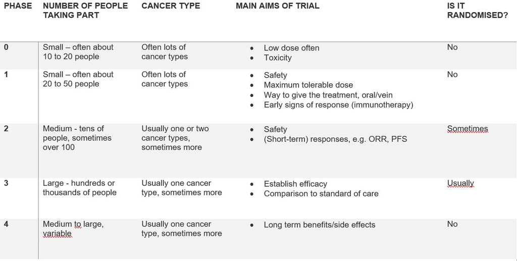

## Phase I trials: Aim

The aim of Phase I trials is to recommend a dose for further investigation in Phase II

- Traditionally in chemotherapy, we often aim for the maximum tolerable dose (MTD)
  - The highest dose with acceptable toxicity
  - Underlying assumption: dose-toxicity closely parallels the dose-response curve

[figure not shown]

## Phase I trials: Aim

The aim of Phase I trials is to recommend a dose for further investigation in Phase II

- With Immuno-/targeted therapies, there is a trend towards optimal biological dose
  - The lowest dose associated with biological efficacy
  - Earlier plateau of efficacy

[figure not shown]

## Phase I trials: Outcome

### If the aim is MTD

- The outcome is usually dose-limiting toxicity (DLT), which is binary (yes/no)
- DLT is evaluated as follows
  - All toxicity events are graded on a scale from 1 (minor) to 4 (severe) according to some criteria, e.g., Common Terminology Criteria for Adverse Events (CTCAE))
  - Toxicity events that are severe enough are considered to be dose-limiting, e.g., grade 3–4 non-haematological, or grade 4 haematological toxicity
  - Varies with each trial
  - If a patient experiences any dose-limiting toxicity, she/he is considered to have a DLT event

### If the aim is OBD

- The outcome also involves objective tumor response in addition to DLT

## Phase I trial: Design (focus on MTD)

### Dose-finding: adjusting the dose as we learn

- Set a target toxicity rate: for example, aim for a dose where about 25% of patients experience a DLT
- Choose the doses to test: a small set of increasing dose levels
- Start cautiously: begin at a low dose expected to have an acceptable toxicity risk
- Learn from each group of patients: use the observed toxicities to decide whether to:
  - Increase the dose
  - Stay at the same dose
  - Decrease the dose
- At the end: recommend a dose with an estimated toxicity rate close to the target

## Phase I trial: Design (focus on MTD)

### 3+3 Design: simple rules, limited information usage

- Workflow: treat 3 patients at a dose the decide
  - 0/3: DLT: increase the dose
  - 1/3: treat 3 more at the current dose
  - 2/3 or more: stop and the lower dose is the MTD
- Commonly used, easy implementation
- Drawback: statistically very inefficient
  - Ignores dosage history other than previous cohort

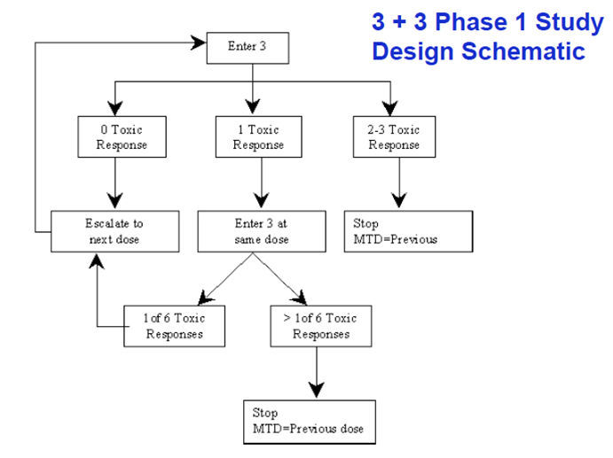

*Source: http://onbiostatistics.blogspot.com/2015/01/phase-i-dose-escalation-study-design-3.html*

## Phase I trial: Design (focus on MTD)

### More efficient design: BOIN

- A refinement of 3+3 design
  - Use more refined decision rules than just “1 out of 3 patients experiencing DLT”
- Can specify target DLT rate
- Easy implementation: can be pre-tabulated!
  - [Website](https://biostatistics.mdanderson.org/shinyapps/BOIN/) for BOIN design

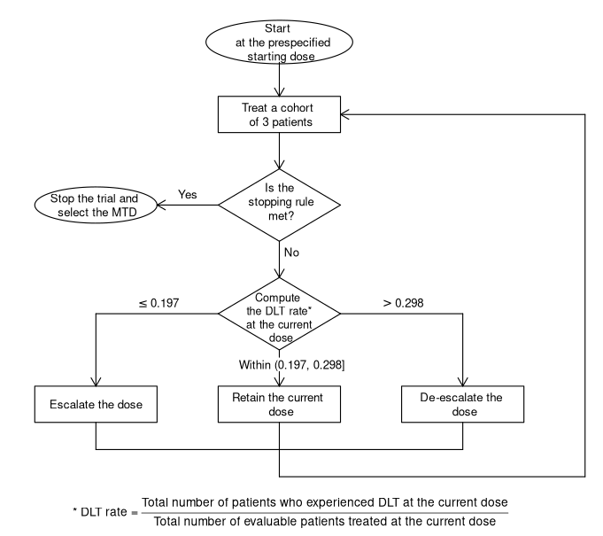

*Source: https://biostatistics.mdanderson.org/shinyapps/BOIN/*

## Phase I trials: Sample size calculation

- Usually no conventional power calculation
  - The aim is to select a dose, rather than test whether a treatment works
- Balance reliable dose selection with patient safety and feasibility
  - In current oncology trials commonly it is 20-40 patients
- Often use simulations to guide planning
  - Run many virtual trials with different sample sizes
  - Check:
    - How often do we select the dose closest to the target toxicity rate?
    - How many patients receive doses that are too toxic?

## Phase I trials: Analysis

- Descriptive statistics

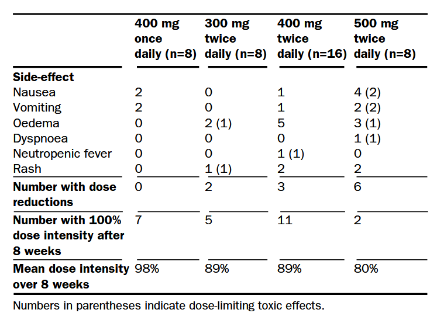

*Safety and efficacy of imatinib (STI571) in metastatic gastrointestinal stromal tumours: a phase I study*

## Phase I trials: To sum up

- [Example protocol template from clinicaltrials.gov](https://cdn.clinicaltrials.gov/documents/trainTrainer/Dose-Escalation-Design-Answer-Key.pdf?utm_source=chatgpt.com)
- [MD Anderson BOIN design website for protocol template of the BOIN design](https://biostatistics.mdanderson.org/shinyapps/BOIN/)

## Phase II trials: Aim

Further confirm safety of the recommended dose

- Safety outcome like DLT still closely monitored

Investigate efficacy

- Look for early evidence of benefit, such as tumour response
- Whether promising enough to initiate a large-scale Phase III investigation

## Phase II trials: Outcome

### Primary efficacy outcome

- Objective tumor response (yes/no, binary)
  - Response Evaluation Criteria in Solid Tumors (RECIST)
- For immuno-/targeted therapies, there’s [findings](https://jamanetwork.com/journals/jamaoncology/fullarticle/2673078) that objective tumor response rate correlated poorly with overall survival
  - Progression-free survival as a closer surrogate for overall survival

We’ll focus on objective tumor response outcome in Phase II and discuss survival outcomes in Phase III

## Phase II trials: Design

Single-arm trial is a common design in oncology

- Practical advantages
  - Easier and faster to initiate than a randomized controlled trial
  - Already lots of data on the performance of the standard of care
  - Patients’ unwillingness to be randomized to standard of care.
  - [Single-arm clinical trials: design, ethics, principles](https://spcare.bmj.com/content/15/1/46)
- Caveat
  - Patients in historical studies may differ in disease severity, previous treatment, or supportive care
  - Better outcomes could therefore reflect differences between patients or settings, rather than a treatment benefit
  - Usually open-label: knowing the treatment may influence care and outcome assessment

## Phase II trials: Sample size calculation

### A refresher of two types of mistakes

- We can be wrong about the conclusion
- Statistical procedures: we’re not making mistakes too often (on average)

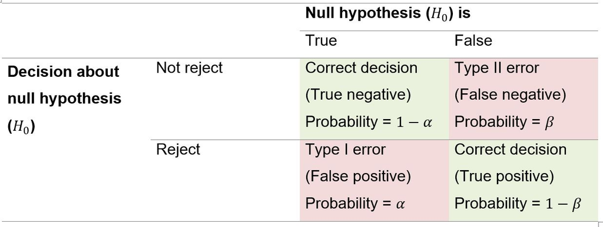

## Phase II trials: Sample size calculation

### Why do sample size calculation?

Sample size calculation is to balance type I error, power, and the size of the effect

- Type I error: pursuing a futile treatment
  - We do not want to investigate further if the treatment is not working
  - Often we control this error rate at 5%
- Power: Detecting a promising treatment
  - If the treatment really works, we want to have high chance of finding this out
  - Often we target 80% power
- Effect size: The effect you won’t want to miss
  - Minimum clinically meaningful effect
  - Not the true effect because we don’t know it before the study

## Phase II trials: Sample size calculation

### An example with binary outcomes

[Phase II, single-arm trial of preoperative short-course radiotherapy followed by chemotherapy and camrelizumab in locally advanced rectal cancer](https://pmc.ncbi.nlm.nih.gov/articles/PMC8562535/#s2)

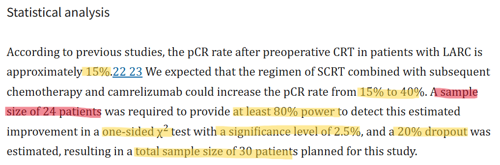

## Phase II trials: Sample size calculation

### An example with binary outcomes

[Sample size calculator for binary outcomes](https://biostatistics.mdanderson.org/shinyapps/Nbinary/)

- They actually did for significance level 5% instead of the intended 2.5%
  - This less strict threshold (because we tolerate higher Type I error rate) resulted in a smaller required sample size
  - The correct calculation would require $31/0.8=39$ (20% drop-out rate)

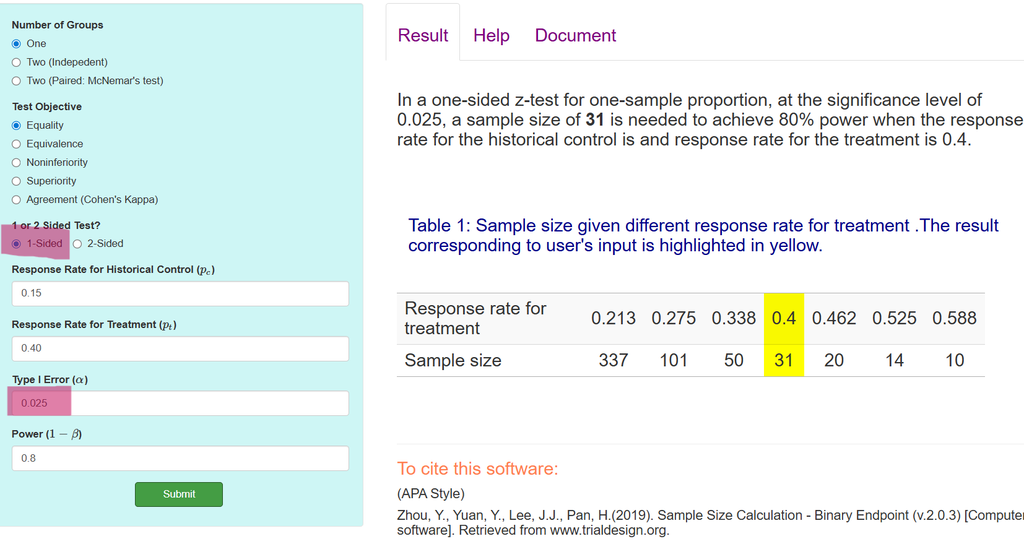

## Phase II trials: Sample size calculation

### An example with binary outcomes

- A two-sided test looks for effects in both directions
  - Puts half of the alpha for positive effect and the other half for negative effects
  - It is the same as a one-sided test with half of the Type I error
- If this sounds confusing – Always do a two-sided test with $5\%$ Type I error :)

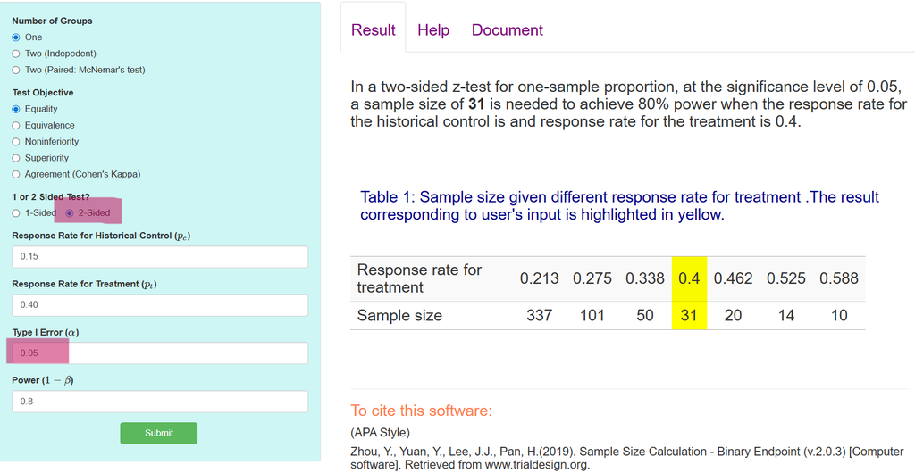

## Phase II trials: Analysis

### Binary outcomes

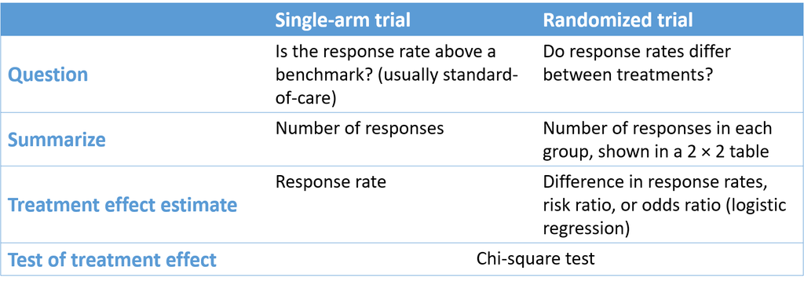

## Phase III trials: Aim & Design

- Establish efficacy
  - Large scale
- Provide evidence for approval
  - Minimize bias
  - Often randomized controlled design with a concurrent standard of care arm

## Phase III trials: Outcome

### Primary efficacy outcome

- Overall survival (OS)
  - Sometimes trial based on progression-free survival (PFS) can receive accelerated approval, but later follow-up on OS is required
- OS and PFS are *time-to-event* outcomes
  - Previously when we consider tumor response, “snapshot”, whether the event of interest happens
  - With time-to-event outcomes, we are interested in how fast the event of interest happens

## Phase III trials: A primer on survival analysis

### Hazard (rate)

- Informally, how quickly patients experience the event of interest (death, relapse, clearance of lesion)

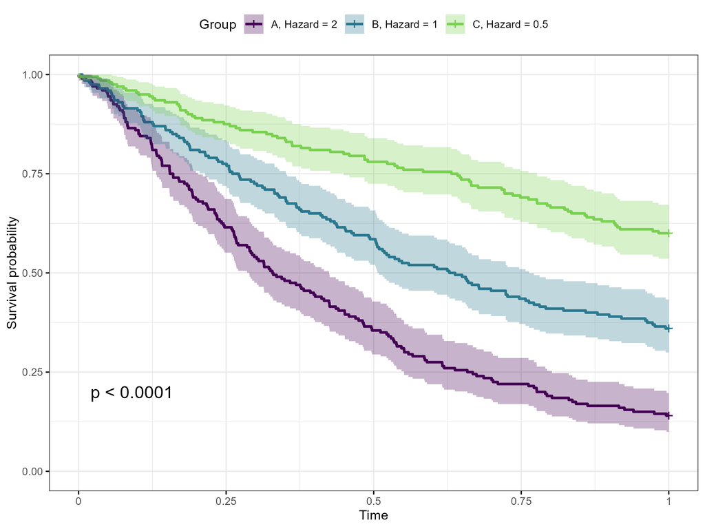

## Phase III trials: A primer on survival analysis

### Hazard ratio (HR)

- The ratio of two hazards between two groups
- Compares the “rate of per unit time” of having the event of interest that applies to every short time interval
  - For instance, HR=2 means that at each day the probability of the event is two times higher in one group compared to the other group.
- Hazard ratio is a relative measure rather than an absolute measure
  - Group comparisons with the same hazard ratio can have very different survival curves
- The treatment slows down disease progression by two folds (HR=0.5)
  - Patients treated could still very poor prognosis because the baseline hazard is high, e.g., pancreatic cancer

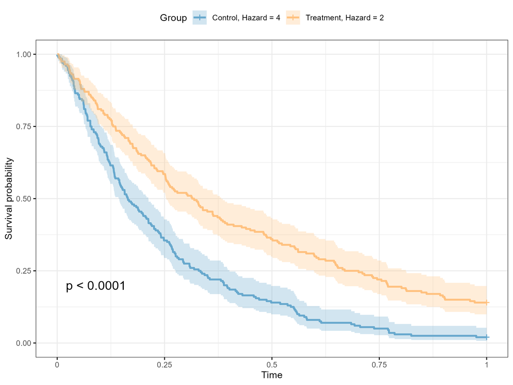

- The treatment slows down disease progression by two folds (HR=0.5)
  - Patients w/w.o. treatment may still have similar mortality over time because the prognosis with standard-of-care is already quite good, e.g., prostate cancer

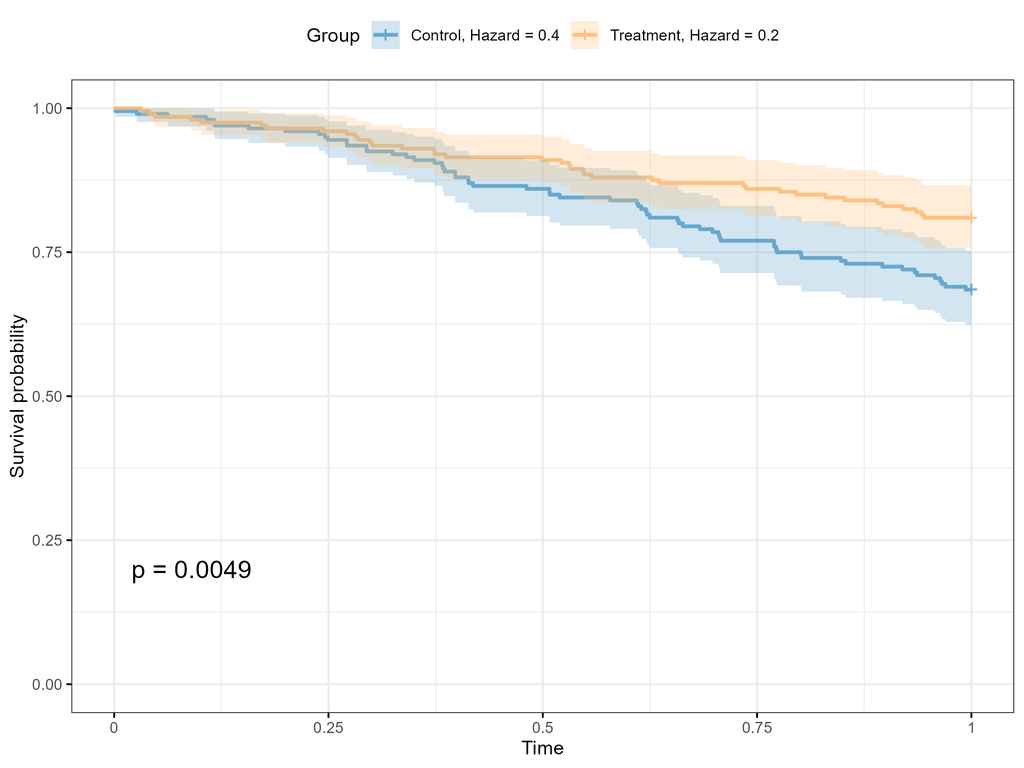

## Phase III trials: A primer on survival analysis

### (Right) Censoring

- It takes time to observe time
- Censoring occurs when true event time is longer than the observed time
  - Fixed study period, administrative censoring (case E), most common in trial setting
  - Loss to follow-up (case A)
  - Withdraw for other reasons (case C)

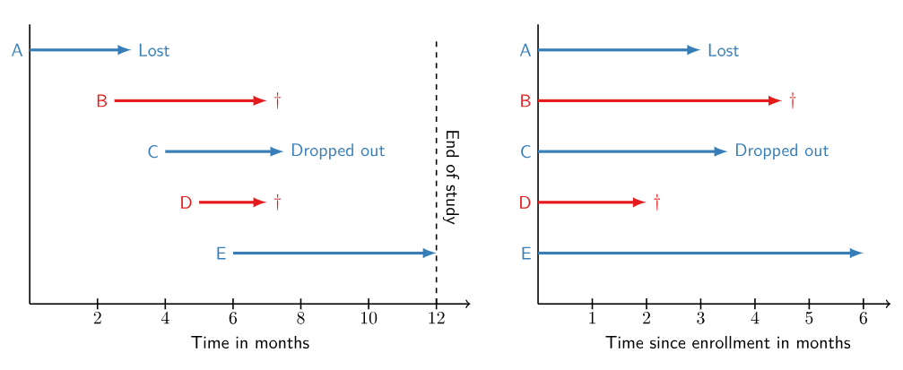

## Phase III trials: Sample size calculation

### An example with time-to-event outcome

Sample size for time-to-event outcomes is really about the number of *events*, not just the number of patients

Sample size for time-to-event outcomes depends on

- 1. How much error we tolerate
  - Type I error, Power
  - The higher error rates we tolerate, the fewer patients needed (but is it a good practice?)

Sample size for time-to-event outcomes depends on

- 2. Effect size
  - Improvement on median OS, Hazard ratio
  - Larger effect sizes are easier to detect, hence fewer patients needed

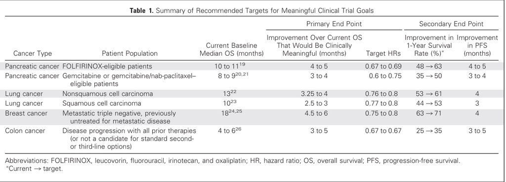

*Source: American Society of Clinical Oncology Perspective: Raising the Bar for Clinical Trials by Defining Clinically Meaningful Outcomes*

Sample size for time-to-event outcomes depends on

- 3. The hazard of event under current standard of care
  - If no patient from either of the treatment arm experiences the event of interest during the whole follow-up, the we can’t tell which treatment is better

Sample size for time-to-event outcomes depends on

- 4. Censoring
  - How fast patients “disappear” from the trial
  - Often due to difficulty in patient accrual
  - Patients entering later will have a shorter period of follow-up

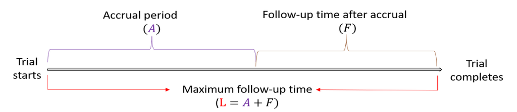

Sample size for time-to-event outcomes depends on

- 5. Allocation ratio
  - 1:1 allocation is statistically most efficient
  - But patients may want higher chance of being randomized to the new intervention

## Phase III trials: Sample size calculation

### An example with time-to-event outcome

Adjuvant chemotherapy with or without bevacizumab in patients with resected non-small-cell lung cancer (E1505) an open-label, multicentre, randomised, phase 3 trial

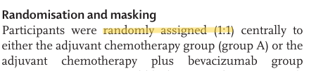

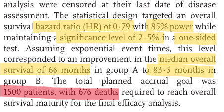

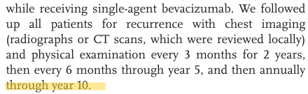

## Phase III trials: Sample size calculation

### An example with time-to-event outcome

[Sample size calculator for time-to-event outcomes](https://biostatistics.mdanderson.org/shinyapps/Nsurvival/)

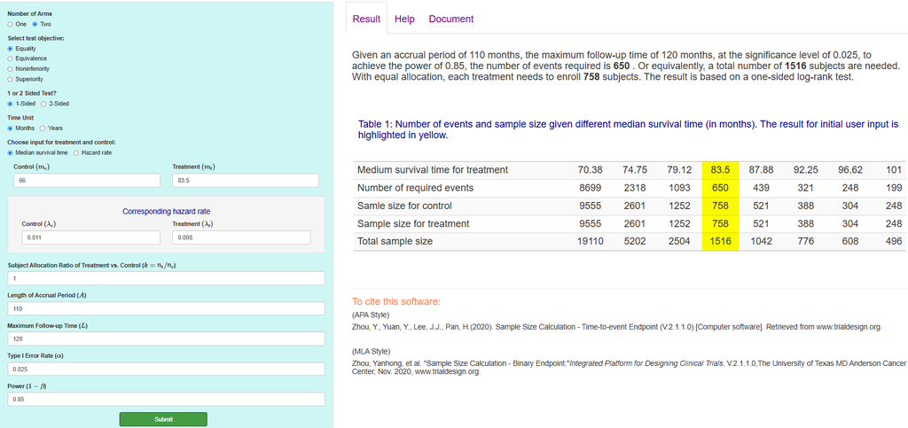

## Phase III trials: Analysis

### Time-to-event outcomes

- Survival probability over time is usually estimated using the Kaplan-Meier curve
- The null hypothesis of no treatment effect (i.e., the two groups have exact the same survival curves) is often tested via
  - log-rank test
- The treatment effect is often quantified by
  - (Adjusted) hazard ratio (for baseline prognostic covariates) via Cox regression

## The END!

## Relevant topics: More on censoring

### When the proportional hazard does not hold (?)

- Pre-specify the analysis time-point to avoid p-hacking
  - 5-year/10-year hazard ratio

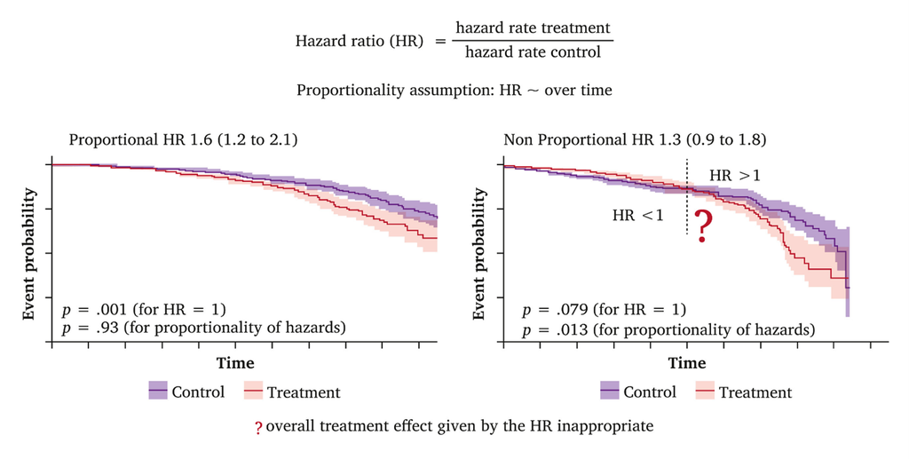

## Relevant topics: More on censoring

### Non-informative vs. informative censoring

- Non-informative censoring: being censored gives no information about the actual risk of the event
  - Administrative censoring is non-informative
  - Loss-to-follow-up due to moving is usually non-informative
- Non-informative censoring does not introduce bias, but adds more uncertainty due to less information

### Different extent of non-informative censoring

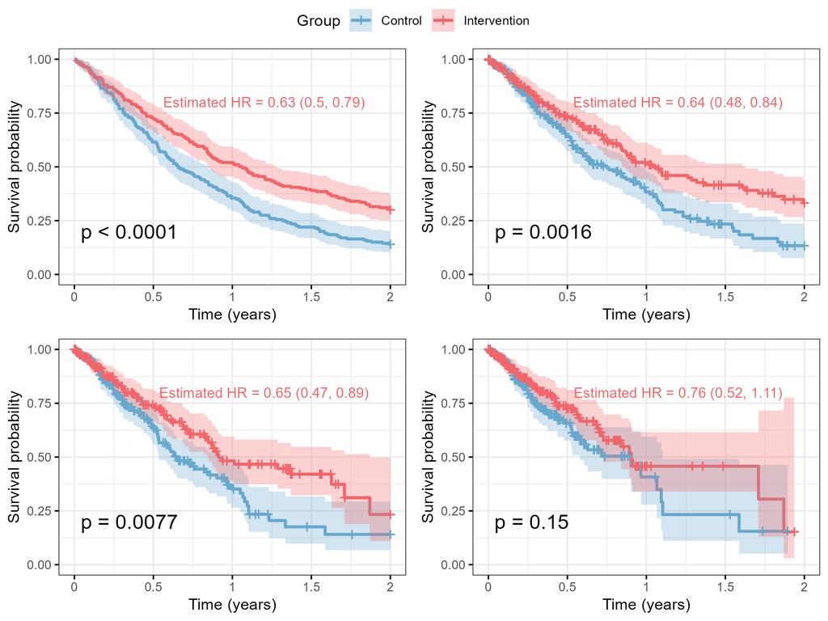

## Relevant topics: More on censoring

### Non-informative vs. informative censoring

- Informative censoring: being censored is related to the actual risk of the event
- Example: The Bolero-2 study
  - Patients on the intervention arm can not tolerate the excess toxicity so they withdraw
  - Censoring them is *Informative*, will bias the treatment effect (which direction?)

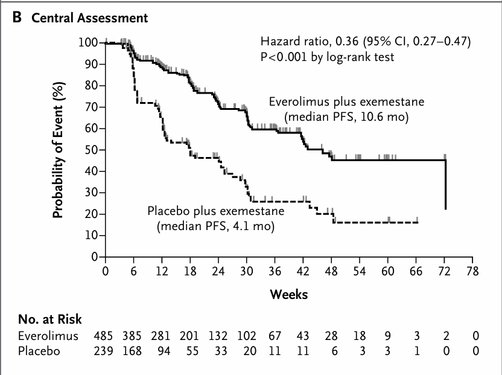

### Informative censoring

- Prevent it at the design stage (best option)
  - Minimize dropouts with good follow-up, reminders, incentives
- Statistical adjustment (e.g., Inverse probability of censoring weighting)

## Relevant topics: Multiple testing

### The fixed “alpha budget”

- In clinical trials, we set a maximum tolerace of a false positive (Type I error), usually 5% ($\alpha = 0.05$)
- This is the “alpha budget.”
- Usually is reserved for testing the main treatment effect on the primary endpoint.
- If we start testing multiple things with the same budget, the chance of at least one false positive increases, unless we control for it

## Relevant topics: Multiple testing

### Interim analysis

- Perhaps you want to peek at your trial data before the planned sample size, to stop earlier for efficacy
- Every interim analysis consumes a bit of the alpha budget
- There are alpha spending functions (e.g., O’Brien-Fleming, Pocock rule) to help you design such interim analyses
  - At the end of the trial, you might not able to reject the null even if your p value is $< 0.05$

## Relevant topics: Multiple testing

### Co-primary outcomes

- Perhaps you think two (or more) outcome measures are equally meaningful so you want to make them co-primary
- The alpha budget has to be split across them
  - Bonferroni correction (testing at half of the alpha level for both)
  - Hierarchical testing (test first outcome at level alpha, if significant, can “gain back” the alpha and test the second outcome still at level alpha)

## Relevant topics: Multiple testing

### Subgroup analysis

- Trials are powered (sample size calculated) for the overall primary outcome, not for subgroups
- Subgroups (e.g., “effect in women only” or “patients over 65”) have smaller sample sizes, so less power
- Subgroup analyses are usually exploratory, unless pre-specified with formal adjustments

## Relevant topics: Non-inferiority trials

- Most trials in oncology test equality of treatment effects
  - Null hypothesis: there is no treatment effect
- Non-inferiority trials aim to show that the new treatment is not unacceptably worse than the control by more than a pre-specified margin, $\delta$
  - Null hypothesis: new treatment is worse than control by more than $\delta$
  - e.g., show that that an oral therapy is not more than 10% worse than IV therapy in survival, but with fewer side effects.
- Why non-inferiority trials?
  - The new treatment might have some benefits other than efficacy
  - Less toxic, cheaper, easier to comply

## Relevant topics: Non-inferiority trials

But non-inferiority trials are hard to conduct

- Has to choose the non-inferiority margin
  - If too wide, risk approving for an inferior treatment. If too narrow, the trial may not be feasible
- Usually much larger sample size requirements

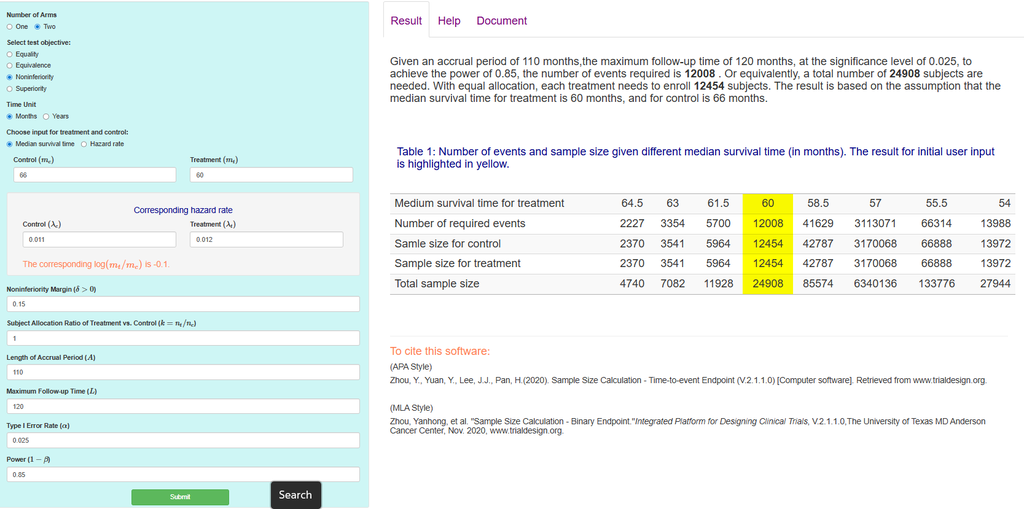